# Open Data Network Business Intelligence Report

## b)

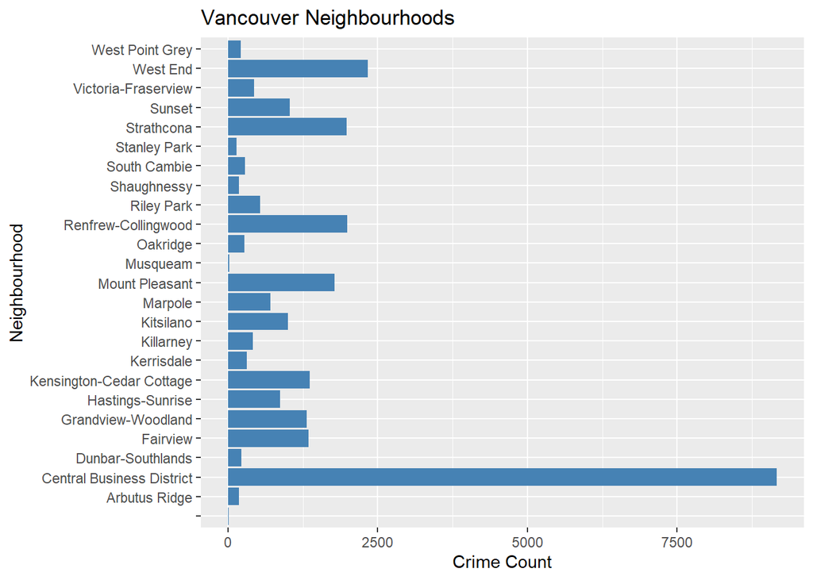

```r
library(ggplot2)
ggplot(data = hood_safety_rank, aes(x = NEIGHBOURHOOD, y = TYPE)) +
    geom_col(fill = "steelblue") +
    coord_flip() +
    labs(title = "Vancouver Neighbourhoods",
         x = "Neighbourhood",
         y = "Crime Count")
```

The Visualization shows crime rates of all recorded neighbourhoods in Vancouver in no particular order, allowing viewers to understand dispersion of crime in the city.

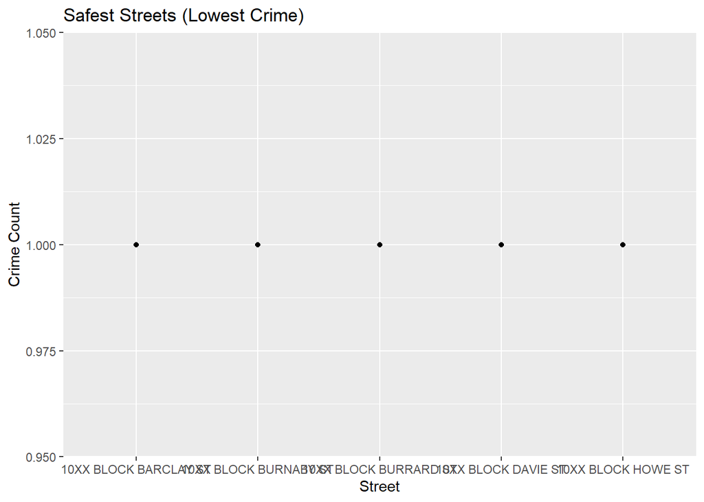

```r
library(ggplot2)
ggplot(data = block_crime, aes(x = HUNDRED_BLOCK, y = TYPE)) +
    geom_point() +
  labs(title = "Safest Streets (Lowest Crime)",
         x = "Street",
         y = "Crime Count")
```

Plot shows the five safest blocks in Vancouver in relation with eachother.

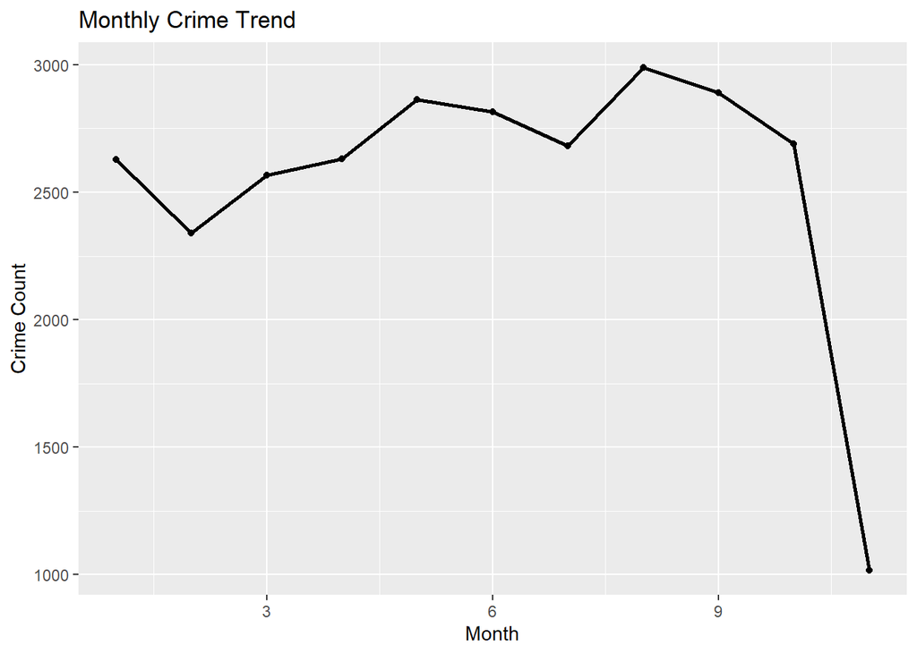

```r
crime_by_month <- aggregate(TYPE ~ MONTH, data = my_data, FUN = length)
library(ggplot2)
ggplot(crime_by_month, aes(x = MONTH, y = TYPE, group = 1)) +
    geom_line(size = 1) +
    geom_point() +
    labs(title = "Monthly Crime Trend",
         x = "Month",
         y = "Crime Count")
```

Line graph representation of crime rate fluctuation throughout the year, recorded in months.

## c)

The data analyzed show that Musqueam, Stanley Park, Shaughnessy, Arbutus Ridge, and West Point Grey are the neighbourhoods with lowest crime incidents, while Barclay, Burnaby, Burrard, Davie, and Howe are the streets with lowest crime rates.

# Strategic Recommendations